# histgadm Usage

Contamin Lucie

2019-08-01

## Installation

You can install the development version of histgadm from [GitHub](https://github.com/epix-project/histgadm) with:

```r
> # install.packages("devtools")
> devtools::install_github("epix-project/histgadm")
```

## Usage

The `histgadm` contains four functions that works together. The function `hist_map` creates historical map, the functions `map_data` & `map_documentation` call the function `hist_map` in the environment of a package and stock the results (maps in `.rda` files and documentation) and download file in the folder corresponding. The function `init_package` called the three functions to create interactively with the user a package containing data, source files and documentation.

```r
> library(histgadm)
```

### `hist_map`

The function `hist_map` creates `sf` objects of historical admin1 administrative boundaries by merging back together, renaming or splitting admin1 polygons from the current admin1 administrative boundaries downloaded from GADM https://gadm.org for one country, one time range and by a list of events provided by the user.

For example, for Vietnam: the user will need to input a list containing the historical event and a dictionary for the admin1, admin2 names (if necessary) . For that, the package `dictionary` can be used as it contains functions to create them but also dictionary and list of event for Cambodia, Laos, Thailand and Vietnam. To install it:

```r
> # install.packages("devtools")
> devtools::install_github("choisy/dictionary")
```

Let’s take a look at it:

```r
> library(dictionary)
> head(vn_admin1) # dictionary for the admin1 names
  An Giang      VN.AG   an giang      vn.ag   AN GIANG      Vn.ag
"An Giang" "An Giang" "An Giang" "An Giang" "An Giang" "An Giang"
> tail(vn_admin1)
        VN-HP         vn-hp         Vn-Hp         VN-SG         vn-sg
  "Hai Phong"   "Hai Phong"   "Hai Phong" "Ho Chi Minh" "Ho Chi Minh"
        Vn-Sg
"Ho Chi Minh"
> head(vn_history, 1) # list of event in admin1 history in vietnam
[[1]]
[[1]]$year
[1] "1990-01-01"

[[1]]$event
[1] "split"

[[1]]$before
[[1]]$before[[1]]
[1] "Binh Tri Thien"


[[1]]$after
[[1]]$after[[1]]
[1] "Quang Binh"

[[1]]$after[[2]]
[1] "Quang Tri"

[[1]]$after[[3]]
[1] "Thua Thien Hue"
```

```r
> a <- hist_map("Vietnam", vn_admin1, vn_history, from = 1980, to = 2019)
The file 'gadm36_VNM_1_sf.rds' is already present in the internal library.
```

We can look in more details at the results

```r
> length(a)
[1] 7
```

and look at the first and last element:

```r
> head(a, 1)
$vn_1980_1990
Simple feature collection with 40 features and 1 field
geometry type:  MULTIPOLYGON
dimension:      XY
bbox:           xmin: 102.145 ymin: 8.563332 xmax: 109.4694 ymax: 23.39273
epsg (SRID):    4326
proj4string:    +proj=longlat +datum=WGS84 +no_defs
First 10 features:
              admin1                       geometry
2           An Giang MULTIPOLYGON (((105.1169 10...
37 Ba Ria - Vung Tau MULTIPOLYGON (((106.1453 8....
26          Bac Thai MULTIPOLYGON (((106.0978 21...
4            Ben Tre MULTIPOLYGON (((106.6384 9....
46    Binh Tri Thien MULTIPOLYGON (((107.9355 16...
27          Cao Bang MULTIPOLYGON (((105.5675 23...
12          Cuu Long MULTIPOLYGON (((106.4053 9....
60          Dack Lak MULTIPOLYGON (((108.1125 12...
36          Dong Nai MULTIPOLYGON (((106.9714 10...
1          Dong Thap MULTIPOLYGON (((105.4328 10...
> tail(a, 1)
$vn_2008_2020
Simple feature collection with 63 features and 1 field
geometry type:  MULTIPOLYGON
dimension:      XY
bbox:           xmin: 102.1446 ymin: 8.381355 xmax: 109.4692 ymax: 23.39269
epsg (SRID):    4326
proj4string:    +proj=longlat +datum=WGS84 +no_defs
First 10 features:
              admin1                       geometry
1           An Giang MULTIPOLYGON (((105.3745 10...
12          Bac Lieu MULTIPOLYGON (((105.4164 9....
23         Bac Giang MULTIPOLYGON (((105.9644 21...
34           Bac Kan MULTIPOLYGON (((105.5904 22...
45          Bac Ninh MULTIPOLYGON (((106.0285 20...
56           Ben Tre MULTIPOLYGON (((106.6355 9....
61 Ba Ria - Vung Tau MULTIPOLYGON (((107.0895 10...
62         Binh Dinh MULTIPOLYGON (((109.3709 13...
63        Binh Duong MULTIPOLYGON (((106.7618 10...
2         Binh Phuoc MULTIPOLYGON (((106.9003 11...
```

We can plot the first and last maps of the list to be able to see the difference:

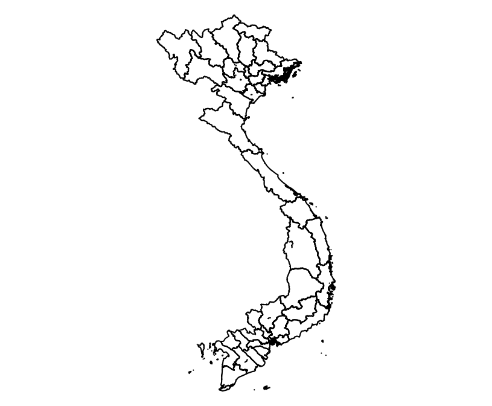

```r
> library(sf)
Linking to GEOS 3.6.1, GDAL 2.1.3, PROJ 4.9.3
> plot(st_geometry(a$vn_1980_1990))
```

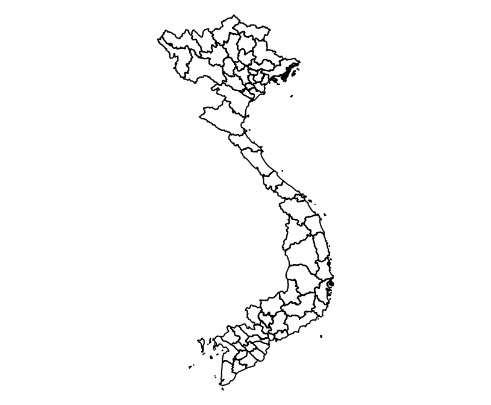

```r
> plot(st_geometry(a$vn_2008_2020))
```

```r
> names(a)
[1] "vn_1980_1990" "vn_1990_1991" "vn_1991_1992" "vn_1992_1997"
[5] "vn_1997_2004" "vn_2004_2008" "vn_2008_2020"
```

Be careful, the historical map are “approximate” map because the package only split or merge back together admin1 polygons when in reality, this event are often more complex.

### `map_data` & `map_documentation`

The users can also use the functions `map_data`, `map_documentation` to complete their packages. Let’s now take a look at `map_data`: it download the current map from GADM and recreates historical map:

```r
> tmp <- file.path(tempdir(), "pkgtest")
> usethis::create_package(tmp, open = FALSE)
✔ Creating '/var/folders/fp/845v7zc96rjdgs2l_86qgy5r0000gn/T/RtmpvXYkOa/pkgtest/'
✔ Setting active project to '/private/var/folders/fp/845v7zc96rjdgs2l_86qgy5r0000gn/T/RtmpvXYkOa/pkgtest'
✔ Creating 'R/'
✔ Writing 'DESCRIPTION'
Package: pkgtest
Title: What the Package Does (One Line, Title Case)
Version: 0.0.0.9000
Authors@R (parsed):
    * First Last <first.last@example.com> [aut, cre] (<https://orcid.org/YOUR-ORCID-ID>)
Description: What the package does (one paragraph).
License: What license it uses
Encoding: UTF-8
LazyData: true
✔ Writing 'NAMESPACE'
✔ Setting active project to '<no active project>'
> histgadm::map_data(tmp, "Cambodia", dictionary::kh_admin1, dictionary::kh_history, from = "1980", to = "2018")
The file 'gadm36_KHM_1_sf.rds' is already present in the internal library.

✔ Setting active project to '/private/var/folders/fp/845v7zc96rjdgs2l_86qgy5r0000gn/T/RtmpvXYkOa/pkgtest'
✔ Saving 'kh_1980_1997', 'kh_1997_2013', 'kh_2013_2019' to 'data/kh_1980_1997.rda', 'data/kh_1997_2013.rda', 'data/kh_2013_2019.rda'
```

The arguments `save` permits to store the source file from gadm in a folder `\data-raw` in the package inputted.

If we look at the folder in the packages:

```r
> dir(paste0(tmp, "/data"))
[1] "kh_1980_1997.rda" "kh_1997_2013.rda" "kh_2013_2019.rda"
> dir(paste0(tmp, "/data-raw"))
[1] "gadm36_KHM_1_sf.rds"
```

And the function `map_documentation` will create the documentation for each object by creating a file `data.R` written in roxygen and a also by creating `.rd` file(s) in the folder `man` of the package.

```r
> map_documentation(tmp)
Updating roxygen version in /private/var/folders/fp/845v7zc96rjdgs2l_86qgy5r0000gn/T/RtmpvXYkOa/pkgtest/DESCRIPTION
Writing NAMESPACE
Loading pkgtest
Writing kh_1980_1997.Rd
Writing kh_1997_2013.Rd
Writing kh_2013_2019.Rd
```

If we look at the folder in the packages:

```r
> dir(paste0(tmp, "/R"))
[1] "data.R"
> dir(paste0(tmp, "/man"))
[1] "kh_1980_1997.Rd" "kh_1997_2013.Rd" "kh_2013_2019.Rd"
```

We can see that documentation corresponding to the object in the package were created: a `.R` file with roxygen comment who was roxigenize to make the files in the `man` folder.

### `init_package`

The function `init_package` creates a package for the GADM data (https://gadm.org/), and interactively allows the user to download data from GADM for one or more country and recreates historical map from a time range (interactive input) by merging or spliting back admin1 polygons. The ouput are `sf` maps of the country with the different admin1 historial and current administrative boundaries.

Below is a quick look at how `histgadm` is working:

```r
> # Create a new package ---------------------------------------------------------
> tmp <- file.path(tempdir(), "pkgtest")
> dir.create(tmp)
> initial_pkg(tmp, "test")
```

By default, the package created contained no data but ask the user to imput at least one country name and a time range to download the data corresponding to and to recreate the historical map corresonding to the time range inputed. Currently, it works only for `Cambodia, Laos, Thailand and Vietnam`.